# Series de Tiempo

Una serie de tiempo es una secuencia de datos medidos en puntos sucesivos en el tiempo con intervalos uniformes

Formalmente **Yt:{y1,y2,…,yT}** donde conocemos los valores de la serie hasta T

## Componentes de una Serie de Tiempo

1. Tendencia: Direccion general a largo plazo
2. Estacionalidad: Patrones que se repiten en intervalos regulares (Por ejemplo: diarios, mensuales & anuales)
3. Ciclos: Fluctuaciones a largo plazo que no son de naturaleza estacional
4. Ruido: Variabilidad aleatoria e impredecible

## Metodos para descomponer series de tiempo

1. Clasica: Separando la serie en sus componentes aditivos o multiplicativos
2. STL (Seasonal and Trend decomposition using Loess): Es un metodo robusto que utiliza regresion local para estimar tendencia y estacionalidad

# Actividad 1

Descargar datos históricos de precios de acciones de Microsoft (MSFT) desde 2010 hasta 2024 utilizando la librería yfinance en Python o tq_get en R.

Calcular y graficar la media móvil de 10 y 30 días para los precios de cierre.

Descomponer la serie de tiempo utilizando el método STL y graficar los componentes resultantes: tendencia, estacionalidad y residuos.

Interpretar los resultados obtenidos y discutir cómo la estacionalidad y la tendencia afectan los precios de las acciones de Microsoft.

```python
import pandas as pd
import yfinance as yf

df = yf.download("MSFT",start="2010-01-01",end="2025-01-01")
df
```

```
[*********************100%***********************]  1 of 1 completed
```

| Price Ticker Date | Close MSFT | High MSFT | Low MSFT | Open MSFT | Volume MSFT |
| --- | --- | --- | --- | --- | --- |
| 2010-01-04 | 23.130054 | 23.242155 | 22.861013 | 22.883434 | 38409100 |
| 2010-01-05 | 23.137535 | 23.242163 | 22.898388 | 23.055329 | 49749600 |
| 2010-01-06 | 22.995533 | 23.227207 | 22.808699 | 23.077739 | 58182400 |
| 2010-01-07 | 22.756386 | 22.943220 | 22.562078 | 22.890905 | 50559700 |
| 2010-01-08 | 22.913328 | 23.077742 | 22.599447 | 22.629341 | 51197400 |
| ... | ... | ... | ... | ... | ... |
| 2024-12-24 | 436.112854 | 436.380896 | 431.010509 | 431.467132 | 7164500 |
| 2024-12-26 | 434.901825 | 437.711119 | 433.432682 | 435.864723 | 8194200 |
| 2024-12-27 | 427.377319 | 432.032978 | 423.227936 | 431.417523 | 18117700 |
| 2024-12-30 | 421.719055 | 424.419138 | 418.810518 | 422.940059 | 13158700 |
| 2024-12-31 | 418.413422 | 423.605134 | 417.579576 | 422.979743 | 13246500 |

3774 rows × 5 columns

```python
precios_cierre = df["Close"]
precios_cierre=precios_cierre.reset_index()
precios_cierre.rename(columns={"MSFT":"Price"}, inplace=True)
precios_cierre.set_index("Date",inplace=True)
precios_cierre.columns.name = None
precios_cierre.head(5)
```

| Date | Price |
| --- | --- |
| 2010-01-04 | 23.130054 |
| 2010-01-05 | 23.137535 |
| 2010-01-06 | 22.995533 |
| 2010-01-07 | 22.756386 |
| 2010-01-08 | 22.913328 |

La serie de tiempo de los Precios de Cierre luce asi:

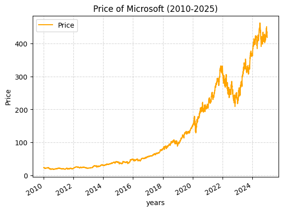

```python
import matplotlib.pyplot as plt

plt.figure(figsize=(9,3))
precios_cierre.plot(color="Orange")
plt.ylabel("Price")
plt.xlabel("years")
plt.grid(True,linestyle="--",alpha=0.5)
plt.title("Price of Microsoft (2010-2025)")
plt.show()
```

### Media Movil (10 y 30 dias)

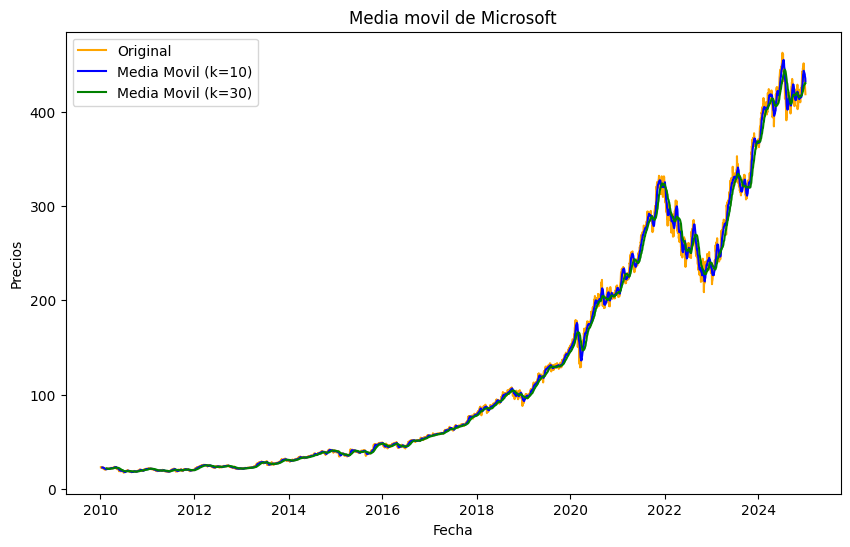

```python
precios_cierre_k10 = precios_cierre.rolling(window=10).mean()
precios_cierre_k30 = precios_cierre.rolling(window=30).mean()

plt.figure(figsize=(10,6))
plt.plot(precios_cierre.index, precios_cierre, label="Original", color="Orange")
plt.plot(precios_cierre.index, precios_cierre_k10, label="Media Movil (k=10)",color="blue")
plt.plot(precios_cierre.index,precios_cierre_k30,label="Media Movil (k=30)",color="green")
plt.title("Media movil de Microsoft")
plt.xlabel("Fecha")
plt.ylabel("Precios")
plt.legend()
plt.show()
```

### STL

Aplicamos **STL** y posteriormente, graficamos cada una de las descompocisiones

```python
from statsmodels.tsa.seasonal import STL

stl = STL(precios_cierre,period=252)
result = stl.fit()

data = {
    "Original":precios_cierre,
    "Tendencia":result.trend,
    "Estacionalidad":result.seasonal,
    "Residuo":result.resid
}
```

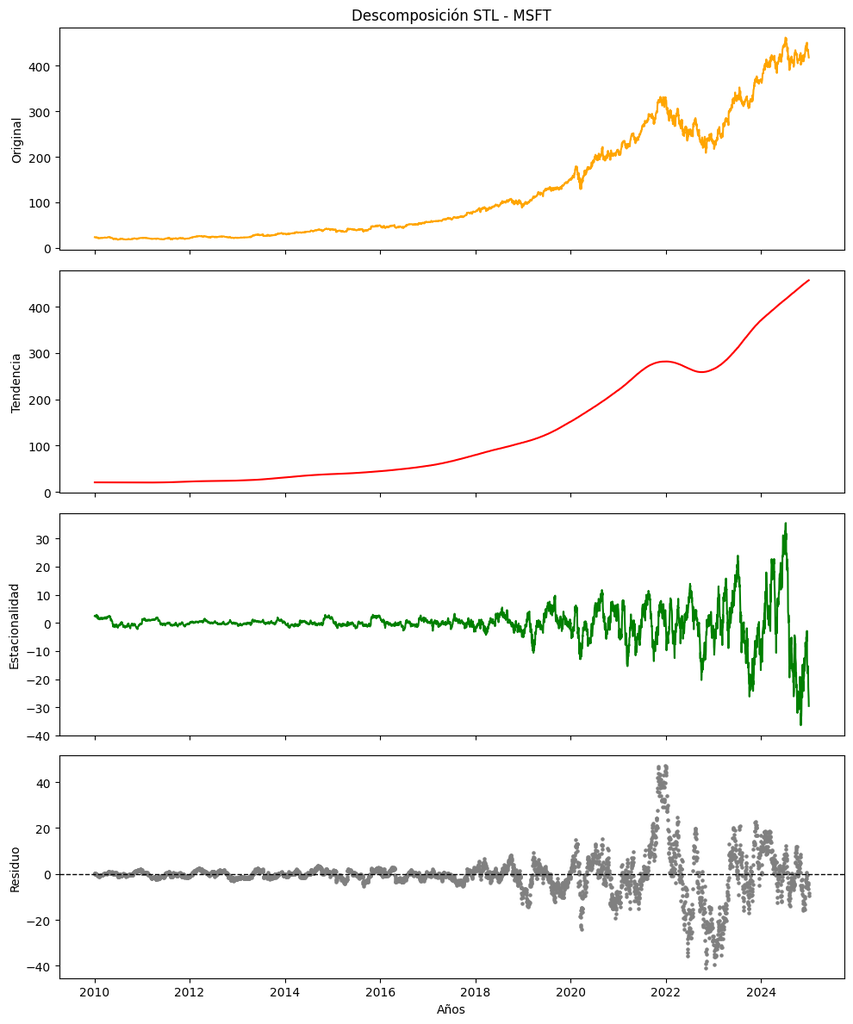

```python
fig, axes = plt.subplots(4, 1, figsize=(10, 12), sharex=True)

# Componente Original
axes[0].plot(precios_cierre.index, precios_cierre['Price'], color='orange')
axes[0].set_ylabel('Original')
axes[0].set_title('Descomposición STL - MSFT')

# Tendencia (Trend)
axes[1].plot(result.trend.index, result.trend, color='red')
axes[1].set_ylabel('Tendencia')

# Estacionalidad (Seasonal)
axes[2].plot(result.seasonal.index, result.seasonal, color='green')
axes[2].set_ylabel('Estacionalidad')

# Residuo (Residual/Noise)
axes[3].scatter(result.resid.index, result.resid, color='gray', s=5)
axes[3].axhline(0, color='black', linestyle='--', linewidth=1)
axes[3].set_ylabel('Residuo')

# 3. Ajustes finales
plt.xlabel('Años')
plt.tight_layout()
plt.show()
```

En cuanto a la **Tendencia** vemos una tendencia alcista y lineal desde 2010 hasta alrededor del 2017 o 2018, despues de aqui la subida fue drastica, vemos este crecimiento debido a que microsoft despues de pandemia ofrecio y crecio mucho su infraestructura en cuanto a la *Cloud & Azure*. Vemos ademas el impacto del post-pandemia entre 2022 o 2023 que hay una pequeña bajada y subida de nuevo

En cuanto a la **Estacionalidad** vemos que en cuanto aumentó los precios de Microsoft alrededor de 2020-2024, la amplitud dela serie de tiempo estacional tambien aumenta lo que nos da a entender que hay un mercado muchisimo mas volatil, ademas vemos que esta entre los 30 dolares por encima y 30 por abajo